# Exam 2

Carolina Herrera Figueroa

11/01/2021

# Instructions

1. Create a folder in your computer (a good place would be under Crim 250, Exams).
2. Download the dataset from the Canvas website (sim.data.csv) onto that folder, and save your Exam 2.Rmd file in the same folder.
3. Data description: This dataset provides (simulated) data about 200 police departments in one year. It contains information about the funding received by the department as well as incidents of police brutality. Suppose this dataset (sim.data.csv) was collected by researchers to answer this question: **“Does having more funding in a police department lead to fewer incidents of police brutality?”**
4. Codebook:
- funds: How much funding the police department received in that year in millions of dollars.
- po.brut: How many incidents of police brutality were reported by the department that year.
- po.dept.code: Police department code

# Problem 1: EDA (10 points)

Describe the dataset and variables. Perform exploratory data analysis for the two variables of interest: funds and po.brut.

```r
dat <- read.csv(file = 'sim.data.csv')
```

```r
dim(dat)
```

```
## [1] 200   3
```

```r
head(dat)
```

```
##   po.dept.code funds po.brut
## 1            1  48.1      23
## 2            2  81.4      10
## 3            3  41.8      25
## 4            4  61.7      19
## 5            5  86.4       8
## 6            6  51.6      22
```

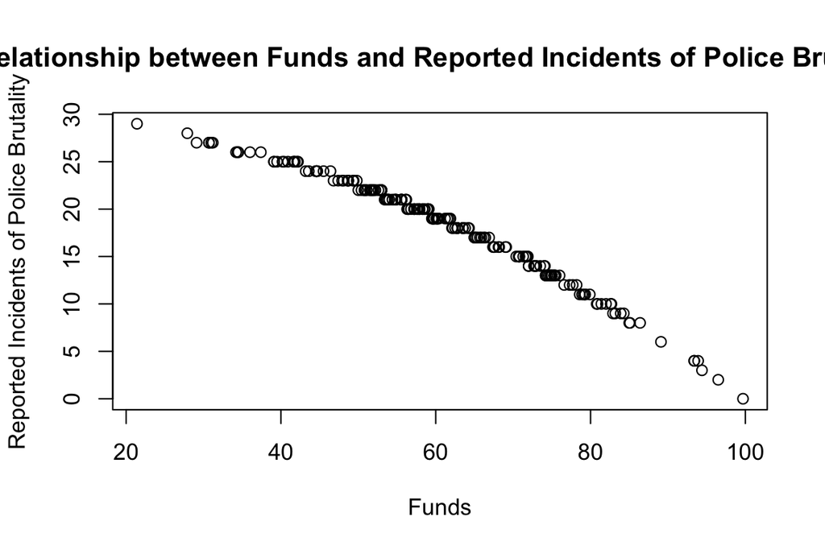

```r
library(datasets)
plot(dat$funds, dat$po.brut, main= "Relationship between Funds and Reported Incidents of Police Brutality",
     xlab = "Funds", ylab= "Reported Incidents of Police Brutality")
```

```r
summary(dat$funds)
```

```
##    Min. 1st Qu.  Median    Mean 3rd Qu.    Max.
##   21.40   51.67   59.75   61.04   72.17   99.70
```

```r
summary(dat$po.brut)
```

```
##    Min. 1st Qu.  Median    Mean 3rd Qu.    Max.
##    0.00   14.00   19.00   18.14   22.00   29.00
```

**There are 200 rows and 3 columns in the dataset. The varibles we have are the police department code (po.dept.code), the amount of funding received by the police department that year in millions of dollars (funds) and the number of incidents of police brutality reported by the department that year (po.brut). The average number of incidents of police brutality is 18.14, and the maximum is 29. The average amount of funds received by a police department that year was 61.04 million dollars. In the scatterplot of the relationship between the variables we can see that there is a curve and also has somewhat of a direction. I would say that there appears to be strong negative relationship between funds and reported incidents of police brutality.**

# Problem 2: Linear regression (30 points)

1. Perform a simple linear regression to answer the question of interest. To do this, name your linear model “reg.output” and write the summary of the regression by using “summary(reg.output)”.

```r
# Remember to remove eval=FALSE!!
reg.output <- lm(formula = po.brut ~ funds, data=dat)
```

```r
summary(reg.output)
```

```
##
## Call:
## lm(formula = po.brut ~ funds, data = dat)
##
## Residuals:
##     Min      1Q  Median      3Q     Max
## -3.9433 -0.2233  0.2544  0.5952  1.1803
##
## Coefficients:
##              Estimate Std. Error t value Pr(>|t|)
## (Intercept) 40.543069   0.282503  143.51   <2e-16 ***
## funds       -0.367099   0.004496  -81.64   <2e-16 ***
## ---
## Signif. codes:  0 '***' 0.001 '**' 0.01 '*' 0.05 '.' 0.1 ' ' 1
##
## Residual standard error: 0.9464 on 198 degrees of freedom
## Multiple R-squared:  0.9712, Adjusted R-squared:  0.971
## F-statistic:  6666 on 1 and 198 DF,  p-value: < 2.2e-16
```

2. Report the estimated coefficient, standard error, and p-value of the slope. Is the relationship between funds and incidents statistically significant? Explain.

**The estimated coefficient is -0.3670, the standard error is 0.0044, and the p-value is 2.2e-16. The slope tells us that an increase of 1 unit in police department funds decreases reported incidents of police brutality by 0.3670 units. Using a significance level of 0.05, the relationship between funds and incidents is statiscally significant because a p-value of 2.2e-16 is much smaller than the significance level (0.05).**

3. Draw a scatterplot of po.brut (y-axis) and funds (x-axis). Right below your plot command, use abline to draw the fitted regression line, like this:

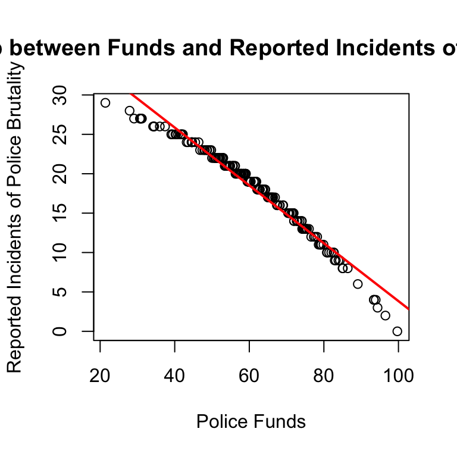

```r
# Remember to remove eval=FALSE!!
library(datasets)
plot(dat$funds, dat$po.brut, main= "Relationship between Funds and Reported Incidents of Police Brutality", xlab= "Police Funds", ylab = "Reported Incidents of Police Brutality")
abline(reg.output, col = "red", lwd=2)
```

Does the line look like a good fit? Why or why not?

4. Are the four assumptions of linear regression satisfied? To answer this, draw the relevant plots. (Write a maximum of one sentence per assumption.) If not, what might you try to do to improve this (if you had more time)?

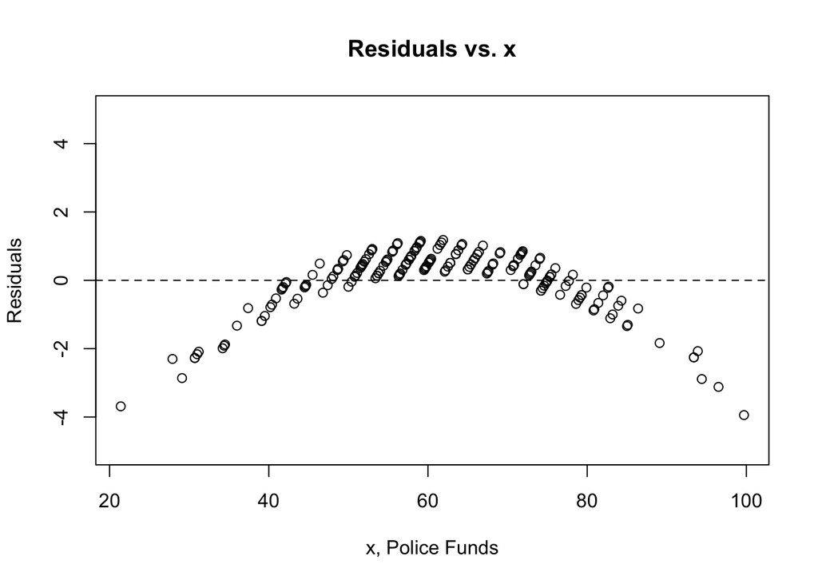

```r
plot(dat$funds, reg.output$residuals, ylim=c(-5,5), main= "Residuals vs. x", xlab= "x, Police Funds", ylab = "Residuals")
abline (h=0, lty="dashed")
```

**The scatterplot for residuals vs. x clearly has a curved pattern around the dashed line - thus the linearity assumption is not satisfied. I would try to use a different model to try to fix this error.**

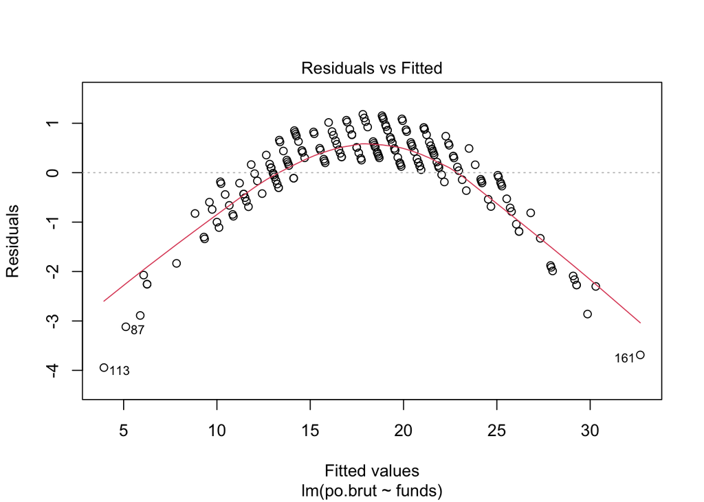

```r
plot(reg.output, which=1)
```

**Looking at the Residuals vs x plot, there are patterns which are not random, suggesting failure of independence, thus the independence assumption is not satisfied.If I had more time I would tranform the variables, either using log or other options.**

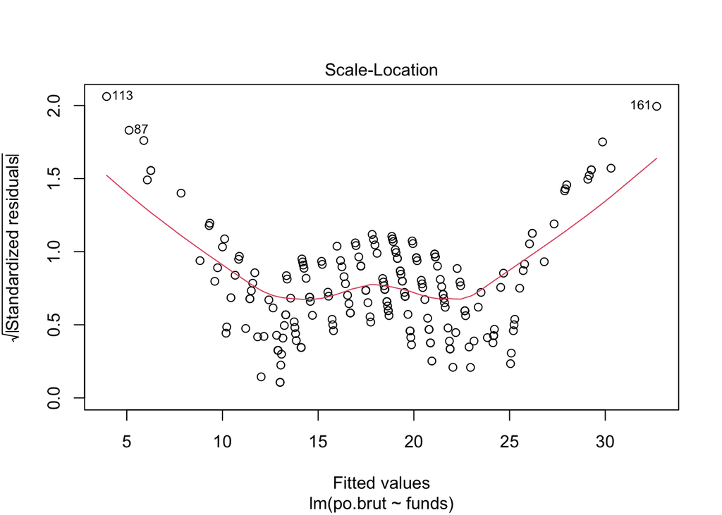

```r
plot(reg.output, which=3)
```

**Here the line is not mostly flat, instead we see it curve upwards on both ends. The residuals are also not randomly scatted around the red line, thus the Equal Variance Assumption is not satisfied.We can use al aternattive statistic to determine if we actually have statistical significance.**

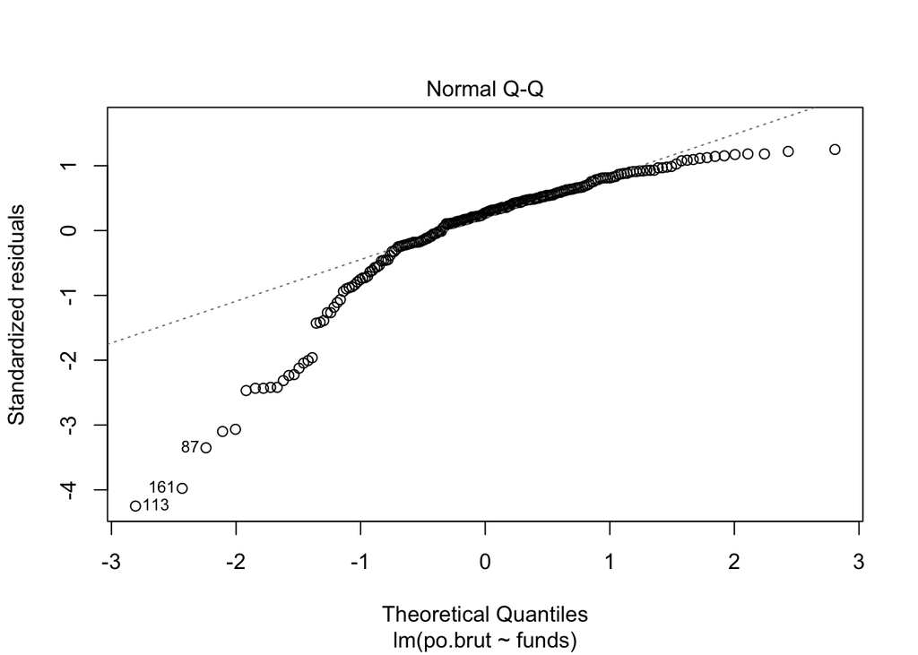

```r
plot(reg.output, which=2)
```

**The Normal Population Assumption is not satisfied because the Q-Q plot appears to have a left skew, we should be cautious about our conclusions. To improve this I would increase the size of the population.**

5. Answer the question of interest based on your analysis.

**I would say that even though the initial scatterplot shows that there is a strong negative relationship between funds and reported incidents of police brutality we must consider the assumptions. None of the 4 assumptions - Linearity, Independece, Equal Variance or Normal Population are satisfied, and thus I would be cautious with stating that there is an association between the variables, even if there appears to be a statistically significant relationship (based on the p-value). Overall, based on our analysis I would say that since the assumptions are not satisfied we cannot conclude that having more funding would lead to fewer incidents of police brutality. Perhaps a different model would yield more conclusive results about the relationship between the two variables of interest.**

# Problem 3: Data ethics (10 points)

Describe the dataset. Considering our lecture on data ethics, what concerns do you have about the dataset? Once you perform your analysis to answer the question of interest using this dataset, what concerns might you have about the results?

**In the dataset it appears that the areas with the highest police funding do indeed have the lowest number of reported incidents of police brutality. I think we must consider a possibility of bias in police recording of the data. The police departments with large funds may not want to report every incident of brutality to avoid being presented in a negative light to the public. There might exist an external variable that we didn’t analyze here that might be affecting the number of reported incidents of police brutality, such as the race or ethnicity of the officers in certain departments. We don’t have this data, but in the future it would be interesting to analyze if there is an association between race and incidents of brutality. If someone was to use the results from this dataset I think it is possible that they may reinforce the biases presented in the data, rather than trying to correct them. Furthermore, underfunded police departments are usually those in low-income neighborhoods and it is possible that people may assume that it is the individuals in the population who are at fault for the rates of brutality.**